# Practical Machine Learning

Winn Chow

15 Oct 2016

## Prediction Assignment Writeup

### Background

Using devices such as Jawbone Up, Nike FuelBand, and Fitbit it is now possible to collect a large amount of data about personal activity relatively inexpensively. These type of devices are part of the quantified self movement – a group of enthusiasts who take measurements about themselves regularly to improve their health, to find patterns in their behavior, or because they are tech geeks. One thing that people regularly do is quantify how much of a particular activity they do, but they rarely quantify how well they do it. In this project, your goal will be to use data from accelerometers on the belt, forearm, arm, and dumbell of 6 participants. They were asked to perform barbell lifts correctly and incorrectly in 5 different ways. More information is available from the website here: http://groupware.les.inf.puc-rio.br/har (see the section on the Weight Lifting Exercise Dataset).

### Data

The training data for this project are available here:

https://d396qusza40orc.cloudfront.net/predmachlearn/pml-training.csv

The test data are available here:

https://d396qusza40orc.cloudfront.net/predmachlearn/pml-testing.csv

### Modeling

Load the caret library for machine learning.

```r
library(caret)
```

### Loading Data

Load the training and testing data. “”, “NA”, and “#DIV/0!” are treated as NAs.

```r
training <- read.csv(file="pml-training.csv", header=TRUE, na.strings = c("", "NA", "#DIV/0!"))
testing <- read.csv(file="pml-testing.csv", header=TRUE, na.strings = c("", "NA", "#DIV/0!"))
```

### Exploring Data

Number of rows and columns in the training data:

```r
nrow(training)
```

```
## [1] 19622
```

```r
ncol(training)
```

```
## [1] 160
```

A bar chart for the response variable, Classe, is shown below.

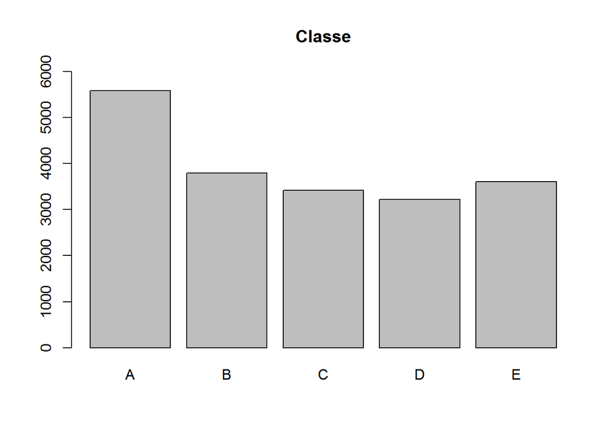

```r
barplot(table(training$classe), main = "Classe", ylim = c(0, 6000))
```

### Cleaning Data

1. Remove descriptive variables: “X”, “user_name”, “raw_timestamp_part_1”, “raw_timestamp_part_2”, “cvtd_timestamp”, “new_window”, “num_window”

```r
dv <- c("X", "user_name", "raw_timestamp_part_1", "raw_timestamp_part_2", "cvtd_timestamp", "new_window", "num_window")
training <- training[, !(names(training) %in% dv)]
```

2. Remove near zero variables

```r
nzv <- nearZeroVar(training)
training <- training[, -nzv]
```

3. Remove variables with more than 30% of NAs

```r
nas <- sapply(training, function(x) { sum(is.na(x)) <= 0.3 * length(training$classe) })
training <- training[, nas]
```

Number of feature variables in the training data now:

```r
ncol(training)
```

```
## [1] 53
```

### Splitting Data into a Training Set and a Validation Set

As the number of available training data is sufficiently large, the validation set approach is used. K-fold cross validation is not used (too time consuming).

```r
set.seed(123123123)
train <- createDataPartition(training$classe, p = 0.7, list = FALSE)
trainingSet <- training[train, ]
ValidationSet <- training[-train, ]
```

### Training

This is a classification problem. Random forest is chosen to be the modeling method. Random forests are usually one of the top performing algorithms in prediction contests. To reduce the training time, I tune the number of trees to be tried out in random forest, ntree, to be 16.

```r
modFit <- train(classe ~ ., data = trainingSet, method = "rf", prox = TRUE, ntree = 16, allowParallel = TRUE)
```

### Training Set Accuracy

Here shows the training set accuracy. My model performs very well with the training set.

```r
p <- predict(modFit, trainingSet)
confusionMatrix(p, trainingSet$classe)
```

```
## Confusion Matrix and Statistics
##
##           Reference
## Prediction    A    B    C    D    E
##          A 3906    1    0    0    0
##          B    0 2657    1    0    0
##          C    0    0 2395    2    0
##          D    0    0    0 2250    0
##          E    0    0    0    0 2525
##
## Overall Statistics
##
##                Accuracy : 0.9997
##                  95% CI : (0.9993, 0.9999)
##     No Information Rate : 0.2843
##     P-Value [Acc > NIR] : < 2.2e-16
##
##                   Kappa : 0.9996
##  Mcnemar's Test P-Value : NA
##
## Statistics by Class:
##
##                      Class: A Class: B Class: C Class: D Class: E
## Sensitivity            1.0000   0.9996   0.9996   0.9991   1.0000
## Specificity            0.9999   0.9999   0.9998   1.0000   1.0000
## Pos Pred Value         0.9997   0.9996   0.9992   1.0000   1.0000
## Neg Pred Value         1.0000   0.9999   0.9999   0.9998   1.0000
## Prevalence             0.2843   0.1935   0.1744   0.1639   0.1838
## Detection Rate         0.2843   0.1934   0.1743   0.1638   0.1838
## Detection Prevalence   0.2844   0.1935   0.1745   0.1638   0.1838
## Balanced Accuracy      0.9999   0.9998   0.9997   0.9996   1.0000
```

### Validation Set Accuracy (Out of Sample)

```r
p <- predict(modFit, ValidationSet)
confusionMatrix(p, ValidationSet$classe)
```

```
## Confusion Matrix and Statistics
##
##           Reference
## Prediction    A    B    C    D    E
##          A 1668    7    0    0    1
##          B    4 1126    7    0    4
##          C    0    4 1011   18    3
##          D    2    2    8  945    4
##          E    0    0    0    1 1070
##
## Overall Statistics
##
##                Accuracy : 0.989
##                  95% CI : (0.9859, 0.9915)
##     No Information Rate : 0.2845
##     P-Value [Acc > NIR] : < 2.2e-16
##
##                   Kappa : 0.986
##  Mcnemar's Test P-Value : NA
##
## Statistics by Class:
##
##                      Class: A Class: B Class: C Class: D Class: E
## Sensitivity            0.9964   0.9886   0.9854   0.9803   0.9889
## Specificity            0.9981   0.9968   0.9949   0.9967   0.9998
## Pos Pred Value         0.9952   0.9869   0.9759   0.9834   0.9991
## Neg Pred Value         0.9986   0.9973   0.9969   0.9961   0.9975
## Prevalence             0.2845   0.1935   0.1743   0.1638   0.1839
## Detection Rate         0.2834   0.1913   0.1718   0.1606   0.1818
## Detection Prevalence   0.2848   0.1939   0.1760   0.1633   0.1820
## Balanced Accuracy      0.9973   0.9927   0.9901   0.9885   0.9944
```

### Testing

Here is the testing result.

```r
p <- predict(modFit, testing)
p
```

```
##  [1] B A B A A E D B A A B C B A E E A B B B
## Levels: A B C D E
```